# TP9 : Merge des bases welfare 2018 et 2021

FALL Ndeye Ramatoulaye Ndoye

2025-03-27

#TP9: Merge des bases welfare des EHCVM 2018 et 2021 du Sénégal en une seule base

# 1. Installation et chargement des packages

Cette section assure la disponibilité des bibliothèques nécessaires.

```r
Packages <- c("readr", "utils", "dplyr","labelled", "gtsummary","haven", "ggplot2", "tidyr", "plotly")

for (x in Packages) {
  if (!requireNamespace(x, quietly = TRUE)) {
    install.packages(x)
  }
  library(x, character.only = TRUE)
}
```

# 2. Importation des bases de données welfare

```r
getwd()
```

```
## [1] "C:/Users/ANSD/Documents/TP9_FALL_Ndeye Ramatoulaye Ndoye/TP9_way/Scripts"
```

```r
welfare2018 <-  haven::read_dta("../Données/ehcvm_welfare_sen2018.dta") #importation base welfare 2018
welfare2021 <-  haven::read_dta("../Données/ehcvm_welfare_sen2021.dta") #importation base welfare 2021
```

# 3. Visualisation des données :

Cette partie va nous permettre de voir la structure des données et d’avoir un aperçu sur les variables. Nous allons examiner les premières lignes de chaque fichier afin de nous assurer qu’ils ont été correctement lus.

```r
# Aperçu des premières lignes pour chaque base

# Cette étape nous permet de vérifier rapidement le format des données
head(welfare2018)
```

```
## # A tibble: 6 × 35
##   country  year  hhid grappe menage vague   zae region   milieu  hhweight hhsize
##   <chr>   <dbl> <dbl>  <dbl>  <dbl> <dbl> <dbl> <dbl+lb> <dbl+l>    <dbl>  <dbl>
## 1 SEN      2018  1001      1      1     1     1 1 [daka… 1 [Urb…    1750.      2
## 2 SEN      2018  1002      1      2     1     1 1 [daka… 1 [Urb…    1750.      2
## 3 SEN      2018  1003      1      3     1     1 1 [daka… 1 [Urb…    1750.      1
## 4 SEN      2018  2001      2      1     2     1 1 [daka… 1 [Urb…     266.     10
## 5 SEN      2018  2002      2      2     2     1 1 [daka… 1 [Urb…     266.      6
## 6 SEN      2018  2003      2      3     2     1 1 [daka… 1 [Urb…     266.      4
## # ℹ 24 more variables: eqadu1 <dbl>, eqadu2 <dbl>, hgender <dbl+lbl>,
## #   hage <dbl>, hmstat <dbl+lbl>, hreligion <dbl+lbl>, hnation <dbl+lbl>,
## #   halfab <dbl+lbl>, heduc <dbl+lbl>, hdiploma <dbl+lbl>, hhandig <dbl+lbl>,
## #   hactiv7j <dbl+lbl>, hactiv12m <dbl+lbl>, hbranch <dbl+lbl>,
## #   hsectins <dbl+lbl>, hcsp <dbl+lbl>, dali <dbl>, dnal <dbl>, dtot <dbl>,
## #   pcexp <dbl>, zzae <dbl>, zref <dbl>, def_spa <dbl>, def_temp <dbl>
```

```r
head(welfare2021)
```

```
## # A tibble: 6 × 47
##   grappe menage country  year  hhid vague month      zae        region   milieu
##    <dbl>  <dbl> <chr>   <dbl> <dbl> <dbl> <date>     <dbl+lbl>  <dbl+lb> <dbl+l>
## 1      2      5 SEN      2021   205     2 2022-05-01 11 [Dakar] 1 [daka… 1 [Urb…
## 2      2     15 SEN      2021   215     2 2022-05-01 11 [Dakar] 1 [daka… 1 [Urb…
## 3      2      3 SEN      2021   203     2 2022-05-01 11 [Dakar] 1 [daka… 1 [Urb…
## 4      2     13 SEN      2021   213     2 2022-05-01 11 [Dakar] 1 [daka… 1 [Urb…
## 5      2      8 SEN      2021   208     2 2022-06-01 11 [Dakar] 1 [daka… 1 [Urb…
## 6      2     16 SEN      2021   216     2 2022-06-01 11 [Dakar] 1 [daka… 1 [Urb…
## # ℹ 37 more variables: hhweight <dbl>, hhsize <dbl>, eqadu1 <dbl>,
## #   eqadu2 <dbl>, hgender <dbl+lbl>, hage <dbl>, hmstat <dbl+lbl>,
## #   hreligion <dbl+lbl>, hnation <dbl+lbl>, hethnie <dbl+lbl>, halfa <dbl+lbl>,
## #   halfa2 <dbl+lbl>, heduc <dbl+lbl>, hdiploma <dbl+lbl>, hhandig <dbl+lbl>,
## #   hactiv7j <dbl+lbl>, hactiv12m <dbl+lbl>, hbranch <dbl+lbl>,
## #   hsectins <dbl+lbl>, hcsp <dbl+lbl>, dali <dbl>, dnal <dbl>, dtot <dbl>,
## #   pcexp <dbl>, zzae <dbl>, zref <dbl>, def_spa <dbl>, def_temp <dbl>, …
```

```r
# Vérification des dimensions des deux bases
# On vérifie combien de lignes et de colonnes chaque base contient
dim(welfare2018)
```

```
## [1] 7156   35
```

```r
dim(welfare2021)
```

```
## [1] 7120   47
```

```r
# Informations générales sur les colonnes/variables
# On utilise str() pour examiner les types de données et les noms de variables
str(welfare2018)
```

```
## tibble [7,156 × 35] (S3: tbl_df/tbl/data.frame)
##  $ country  : chr [1:7156] "SEN" "SEN" "SEN" "SEN" ...
##   ..- attr(*, "label")= chr "Pays"
##   ..- attr(*, "format.stata")= chr "%3s"
##  $ year     : num [1:7156] 2018 2018 2018 2018 2018 ...
##   ..- attr(*, "label")= chr "Annee enquete"
##   ..- attr(*, "format.stata")= chr "%8.0g"
##  $ hhid     : num [1:7156] 1001 1002 1003 2001 2002 ...
##   ..- attr(*, "label")= chr "Idenfiant menage"
##   ..- attr(*, "format.stata")= chr "%12.0g"
##  $ grappe   : num [1:7156] 1 1 1 2 2 2 2 2 2 2 ...
##   ..- attr(*, "label")= chr "Numero grappe"
##   ..- attr(*, "format.stata")= chr "%8.0g"
##  $ menage   : num [1:7156] 1 2 3 1 2 3 4 5 6 7 ...
##   ..- attr(*, "label")= chr "Numero menage"
##   ..- attr(*, "format.stata")= chr "%8.0g"
##  $ vague    : num [1:7156] 1 1 1 2 2 2 2 2 2 2 ...
##   ..- attr(*, "label")= chr "Vague"
##   ..- attr(*, "format.stata")= chr "%8.0g"
##  $ zae      : num [1:7156] 1 1 1 1 1 1 1 1 1 1 ...
##   ..- attr(*, "label")= chr "Zone agroecologique"
##   ..- attr(*, "format.stata")= chr "%8.0g"
##  $ region   : dbl+lbl [1:7156] 1, 1, 1, 1, 1, 1, 1, 1, 1, 1, 1, 1, 1, 1, 1, 1, 1, 1,...
##    ..@ label       : chr "Region residence"
##    ..@ format.stata: chr "%8.0g"
##    ..@ labels      : Named num [1:14] 1 2 3 4 5 6 7 8 9 10 ...
##    .. ..- attr(*, "names")= chr [1:14] "dakar" "ziguinchor" "diourbel" "SAINT-LOUIS" ...
##  $ milieu   : dbl+lbl [1:7156] 1, 1, 1, 1, 1, 1, 1, 1, 1, 1, 1, 1, 1, 1, 1, 1, 1, 1,...
##    ..@ label       : chr "Milieu residence"
##    ..@ format.stata: chr "%8.0g"
##    ..@ labels      : Named num [1:2] 1 2
##    .. ..- attr(*, "names")= chr [1:2] "Urbain" "Rural"
##  $ hhweight : num [1:7156] 1750 1750 1750 266 266 ...
##   ..- attr(*, "label")= chr "Ponderation menage"
##   ..- attr(*, "format.stata")= chr "%9.0g"
##  $ hhsize   : num [1:7156] 2 2 1 10 6 4 3 2 3 1 ...
##   ..- attr(*, "label")= chr "Taille menage"
##   ..- attr(*, "format.stata")= chr "%8.0g"
##  $ eqadu1   : num [1:7156] 1.32 1.45 1 7.66 4.28 ...
##   ..- attr(*, "label")= chr "Nbr adultes-equiv. FAO"
```

[output cut: 80 more lines]

```
##   ..- attr(*, "format.stata")= chr "%12.0g"
##  $ pcexp    : num [1:7156] 6440507 4593088 4638249 976281 893649 ...
##   ..- attr(*, "label")= chr "Indicateur de bien-être"
##   ..- attr(*, "format.stata")= chr "%12.0g"
##  $ zzae     : num [1:7156] 391340 391340 391340 391340 391340 ...
##   ..- attr(*, "format.stata")= chr "%12.0g"
##  $ zref     : num [1:7156] 333441 333441 333441 333441 333441 ...
##   ..- attr(*, "label")= chr "Seuil pauvrete national"
##   ..- attr(*, "format.stata")= chr "%12.0g"
##  $ def_spa  : num [1:7156] 1.17 1.17 1.17 1.17 1.17 ...
##   ..- attr(*, "label")= chr "Deflateur spatial"
##   ..- attr(*, "format.stata")= chr "%9.0g"
##  $ def_temp : num [1:7156] 1.015 1.012 1.015 0.992 0.992 ...
##   ..- attr(*, "label")= chr "Deflateur temporel"
##   ..- attr(*, "format.stata")= chr "%9.0g"
```

```r
str(welfare2021)
```

```
## tibble [7,120 × 47] (S3: tbl_df/tbl/data.frame)
##  $ grappe              : num [1:7120] 2 2 2 2 2 2 2 2 2 2 ...
##   ..- attr(*, "label")= chr "grappe"
##   ..- attr(*, "format.stata")= chr "%8.0g"
##  $ menage              : num [1:7120] 5 15 3 13 8 16 7 4 1 12 ...
##   ..- attr(*, "label")= chr "Identifiant du ménage"
##   ..- attr(*, "format.stata")= chr "%8.0g"
##  $ country             : chr [1:7120] "SEN" "SEN" "SEN" "SEN" ...
##   ..- attr(*, "label")= chr "Pays"
##   ..- attr(*, "format.stata")= chr "%3s"
##  $ year                : num [1:7120] 2021 2021 2021 2021 2021 ...
##   ..- attr(*, "label")= chr "Annee enquete"
##   ..- attr(*, "format.stata")= chr "%8.0g"
##  $ hhid                : num [1:7120] 205 215 203 213 208 216 207 204 201 212 ...
##   ..- attr(*, "label")= chr "Idenfiant menage"
##   ..- attr(*, "format.stata")= chr "%12.0g"
##  $ vague               : num [1:7120] 2 2 2 2 2 2 2 2 2 2 ...
##   ..- attr(*, "label")= chr "Vague"
##   ..- attr(*, "format.stata")= chr "%8.0g"
##  $ month               : Date[1:7120], format: "2022-05-01" "2022-05-01" ...
##  $ zae                 : dbl+lbl [1:7120] 11, 11, 11, 11, 11, 11, 11, 11, 11, 11, 11, 11, 11, 1...
##    ..@ label       : chr "Zone agroecologique"
##    ..@ format.stata: chr "%8.0g"
##    ..@ labels      : Named num [1:6] 1 3 5 7 9 11
##    .. ..- attr(*, "names")= chr [1:6] "Kédougou" "Saint-Louis-Matam" "Thies-Diourbel-Louga" "Kaolack-Fatick-Kaffrine" ...
##  $ region              : dbl+lbl [1:7120] 1, 1, 1, 1, 1, 1, 1, 1, 1, 1, 1, 1, 1, 1, 1, 1, 1, 1,...
##    ..@ label       : chr "Region residence"
##    ..@ format.stata: chr "%8.0g"
##    ..@ labels      : Named num [1:14] 1 2 3 4 5 6 7 8 9 10 ...
##    .. ..- attr(*, "names")= chr [1:14] "dakar" "ziguinchor" "diourbel" "SAINT-LOUIS" ...
##  $ milieu              : dbl+lbl [1:7120] 1, 1, 1, 1, 1, 1, 1, 1, 1, 1, 1, 1, 1, 1, 1, 1, 1, 1,...
##    ..@ label       : chr "Milieu residence"
##    ..@ format.stata: chr "%8.0g"
##    ..@ labels      : Named num [1:2] 1 2
##    .. ..- attr(*, "names")= chr [1:2] "Urbain" "Rural"
##  $ hhweight            : num [1:7120] 386 386 386 386 290 ...
##   ..- attr(*, "label")= chr "Ponderation menage"
##   ..- attr(*, "format.stata")= chr "%12.0g"
##  $ hhsize              : num [1:7120] 3 2 3 5 1 5 1 3 9 6 ...
##   ..- attr(*, "label")= chr "Taille menage"
```

[output cut: 117 more lines]

```
##  $ zali0               : num [1:7120] 196233 196233 196233 196233 196233 ...
##   ..- attr(*, "label")= chr "(sum) conso_pc_val_up"
##   ..- attr(*, "format.stata")= chr "%12.0g"
##  $ dtet                : num [1:7120] 769710 911466 1142771 977906 2515290 ...
##   ..- attr(*, "format.stata")= chr "%12.0g"
##  $ monthly_cpi         : num [1:7120] 120 120 120 120 123 ...
##   ..- attr(*, "label")= chr "Monthly CPI value"
##   ..- attr(*, "format.stata")= chr "%12.0g"
##  $ cpi2017             : num [1:7120] 1.1 1.1 1.1 1.1 1.1 ...
##   ..- attr(*, "format.stata")= chr "%9.0g"
##  $ icp2017             : num [1:7120] 239 239 239 239 239 ...
##   ..- attr(*, "format.stata")= chr "%12.0g"
##  $ dollars             : num [1:7120] 7.71 9.12 11.44 9.79 25.79 ...
##   ..- attr(*, "label")= chr "welfare in 2017 PPP USD per capita per day (not spatially deflated)"
##   ..- attr(*, "format.stata")= chr "%9.0g"
```

```r
colnames(welfare2018)
```

```
##  [1] "country"   "year"      "hhid"      "grappe"    "menage"    "vague"
##  [7] "zae"       "region"    "milieu"    "hhweight"  "hhsize"    "eqadu1"
## [13] "eqadu2"    "hgender"   "hage"      "hmstat"    "hreligion" "hnation"
## [19] "halfab"    "heduc"     "hdiploma"  "hhandig"   "hactiv7j"  "hactiv12m"
## [25] "hbranch"   "hsectins"  "hcsp"      "dali"      "dnal"      "dtot"
## [31] "pcexp"     "zzae"      "zref"      "def_spa"   "def_temp"
```

```r
colnames(welfare2021)
```

```
##  [1] "grappe"               "menage"               "country"
##  [4] "year"                 "hhid"                 "vague"
##  [7] "month"                "zae"                  "region"
## [10] "milieu"               "hhweight"             "hhsize"
## [13] "eqadu1"               "eqadu2"               "hgender"
## [16] "hage"                 "hmstat"               "hreligion"
## [19] "hnation"              "hethnie"              "halfa"
## [22] "halfa2"               "heduc"                "hdiploma"
## [25] "hhandig"              "hactiv7j"             "hactiv12m"
## [28] "hbranch"              "hsectins"             "hcsp"
## [31] "dali"                 "dnal"                 "dtot"
## [34] "pcexp"                "zzae"                 "zref"
## [37] "def_spa"              "def_temp"             "def_temp_prix2021m11"
## [40] "def_temp_cpi"         "def_temp_adj"         "zali0"
## [43] "dtet"                 "monthly_cpi"          "cpi2017"
## [46] "icp2017"              "dollars"
```

# 4. Vérification de la qualité des données :

Nous allons maintenant vérifier la qualité des données, où nous allons analyser la présence de valeurs manquantes et de doublons, et vérifier que les types de données sont cohérents avec les variables attendues. Cette étape nous permettra d’identifier les anomalies.

## a) Valeurs manquantes

```r
# Vérification des valeurs manquantes
# Cette étape permet de détecter la présence de données manquantes
summary(welfare2018)
```

```
##    country               year           hhid            grappe
##  Length:7156        Min.   :2018   Min.   :  1001   Min.   :  1.0
##  Class :character   1st Qu.:2018   1st Qu.:151002   1st Qu.:151.0
##  Mode  :character   Median :2018   Median :300003   Median :300.0
##                     Mean   :2018   Mean   :299934   Mean   :299.9
##                     3rd Qu.:2018   3rd Qu.:449010   3rd Qu.:449.0
##                     Max.   :2018   Max.   :598012   Max.   :598.0
##
##      menage           vague            zae            region
##  Min.   : 1.000   Min.   :1.000   Min.   :1.000   Min.   : 1.000
##  1st Qu.: 3.000   1st Qu.:1.000   1st Qu.:2.000   1st Qu.: 3.000
##  Median : 6.000   Median :2.000   Median :4.000   Median : 7.000
##  Mean   : 6.491   Mean   :1.501   Mean   :3.466   Mean   : 6.781
##  3rd Qu.: 9.000   3rd Qu.:2.000   3rd Qu.:5.000   3rd Qu.:10.000
##  Max.   :12.000   Max.   :2.000   Max.   :6.000   Max.   :14.000
##
##      milieu         hhweight           hhsize          eqadu1
##  Min.   :1.000   Min.   :  15.29   Min.   : 1.00   Min.   : 0.660
##  1st Qu.:1.000   1st Qu.: 120.57   1st Qu.: 5.00   1st Qu.: 3.960
##  Median :1.000   Median : 203.88   Median : 8.00   Median : 5.982
##  Mean   :1.449   Mean   : 250.38   Mean   : 9.24   Mean   : 6.867
##  3rd Qu.:2.000   3rd Qu.: 322.74   3rd Qu.:12.00   3rd Qu.: 8.720
##  Max.   :2.000   Max.   :2808.65   Max.   :56.00   Max.   :41.240
##
##      eqadu2          hgender           hage           hmstat
##  Min.   : 1.000   Min.   :1.000   Min.   :17.00   Min.   :1.000
##  1st Qu.: 3.167   1st Qu.:1.000   1st Qu.:41.00   1st Qu.:2.000
##  Median : 4.333   Median :1.000   Median :51.00   Median :2.000
##  Mean   : 4.811   Mean   :1.262   Mean   :51.49   Mean   :2.704
##  3rd Qu.: 5.984   3rd Qu.:2.000   3rd Qu.:62.00   3rd Qu.:3.000
##  Max.   :23.706   Max.   :2.000   Max.   :99.00   Max.   :7.000
##                                                   NA's   :2
##    hreligion        hnation           halfab           heduc
##  Min.   :1.000   Min.   : 2.000   Min.   :0.0000   Min.   :1.000
##  1st Qu.:1.000   1st Qu.: 7.000   1st Qu.:0.0000   1st Qu.:1.000
##  Median :1.000   Median : 7.000   Median :0.0000   Median :1.000
##  Mean   :1.061   Mean   : 7.024   Mean   :0.4707   Mean   :2.188
##  3rd Qu.:1.000   3rd Qu.: 7.000   3rd Qu.:1.0000   3rd Qu.:3.000
##  Max.   :5.000   Max.   :12.000   Max.   :1.0000   Max.   :9.000
##
```

[output cut: 17 more lines]

```
##  Min.   :    27585   Min.   :   278116   Min.   :   64161   Min.   :296311
##  1st Qu.:   990977   1st Qu.:  2268859   1st Qu.:  300149   1st Qu.:305745
##  Median :  1632298   Median :  3484846   Median :  442539   Median :326047
##  Mean   :  2268143   Mean   :  4332005   Mean   :  615630   Mean   :332244
##  3rd Qu.:  2771981   3rd Qu.:  5391925   3rd Qu.:  697134   3rd Qu.:348125
##  Max.   :221582921   Max.   :227607152   Max.   :14286279   Max.   :391340
##
##       zref           def_spa          def_temp
##  Min.   :333441   Min.   :0.8886   Min.   :0.9916
##  1st Qu.:333441   1st Qu.:0.9169   1st Qu.:0.9916
##  Median :333441   Median :0.9778   Median :0.9955
##  Mean   :333441   Mean   :0.9964   Mean   :1.0015
##  3rd Qu.:333441   3rd Qu.:1.0440   3rd Qu.:1.0089
##  Max.   :333441   Max.   :1.1736   Max.   :1.0147
##
```

```r
summary(welfare2021)
```

```
##      grappe          menage         country               year
##  Min.   :  2.0   Min.   : 1.000   Length:7120        Min.   :2021
##  1st Qu.:152.0   1st Qu.: 4.000   Class :character   1st Qu.:2021
##  Median :301.0   Median : 7.000   Mode  :character   Median :2021
##  Mean   :300.7   Mean   : 7.187                      Mean   :2021
##  3rd Qu.:450.0   3rd Qu.:10.000                      3rd Qu.:2021
##  Max.   :598.0   Max.   :19.000                      Max.   :2021
##
##       hhid           vague           month                 zae
##  Min.   :  201   Min.   :1.000   Min.   :2021-11-01   Min.   : 1.000
##  1st Qu.:15208   1st Qu.:1.000   1st Qu.:2021-12-01   1st Qu.: 5.000
##  Median :30103   Median :2.000   Median :2022-04-01   Median : 7.000
##  Mean   :30082   Mean   :1.503   Mean   :2022-02-16   Mean   : 6.712
##  3rd Qu.:45004   3rd Qu.:2.000   3rd Qu.:2022-05-01   3rd Qu.: 9.000
##  Max.   :59812   Max.   :2.000   Max.   :2022-07-01   Max.   :11.000
##
##      region           milieu         hhweight           hhsize
##  Min.   : 1.000   Min.   :1.000   Min.   :  17.73   Min.   : 1.000
##  1st Qu.: 3.000   1st Qu.:1.000   1st Qu.: 131.07   1st Qu.: 5.000
##  Median : 7.000   Median :1.000   Median : 221.81   Median : 8.000
##  Mean   : 6.799   Mean   :1.449   Mean   : 297.44   Mean   : 8.747
##  3rd Qu.:10.000   3rd Qu.:2.000   3rd Qu.: 380.29   3rd Qu.:11.000
##  Max.   :14.000   Max.   :2.000   Max.   :3081.51   Max.   :53.000
##
##      eqadu1           eqadu2          hgender           hage
##  Min.   : 0.660   Min.   : 1.000   Min.   :1.000   Min.   : 16.00
##  1st Qu.: 3.940   1st Qu.: 3.008   1st Qu.:1.000   1st Qu.: 44.00
##  Median : 5.790   Median : 4.180   Median :1.000   Median : 54.00
##  Mean   : 6.589   Mean   : 4.625   Mean   :1.284   Mean   : 54.08
##  3rd Qu.: 8.350   3rd Qu.: 5.762   3rd Qu.:2.000   3rd Qu.: 64.00
##  Max.   :40.265   Max.   :22.882   Max.   :2.000   Max.   :101.00
##
##      hmstat        hreligion        hnation         hethnie
##  Min.   :1.000   Min.   :1.000   Min.   : 4.00   Min.   : 1.000
##  1st Qu.:2.000   1st Qu.:1.000   1st Qu.:13.00   1st Qu.: 1.000
##  Median :2.000   Median :1.000   Median :13.00   Median : 3.000
##  Mean   :2.805   Mean   :1.058   Mean   :12.95   Mean   : 3.096
##  3rd Qu.:3.000   3rd Qu.:1.000   3rd Qu.:13.00   3rd Qu.: 3.000
##  Max.   :7.000   Max.   :5.000   Max.   :18.00   Max.   :13.000
##                                                  NA's   :82
```

[output cut: 41 more lines]

```
##  Min.   :0.9606   Min.   :196233   Min.   :   50712   Min.   :117.2
##  1st Qu.:0.9991   1st Qu.:196233   1st Qu.:  317994   1st Qu.:117.4
##  Median :1.0109   Median :196233   Median :  469028   Median :119.6
##  Mean   :1.0140   Mean   :196233   Mean   :  641538   Mean   :119.6
##  3rd Qu.:1.0363   3rd Qu.:196233   3rd Qu.:  746041   3rd Qu.:120.4
##  Max.   :1.0760   Max.   :196233   Max.   :10366096   Max.   :127.4
##
##     cpi2017         icp2017         dollars
##  Min.   :1.097   Min.   :238.6   Min.   :  0.5376
##  1st Qu.:1.097   1st Qu.:238.6   1st Qu.:  3.2473
##  Median :1.097   Median :238.6   Median :  4.7915
##  Mean   :1.097   Mean   :238.6   Mean   :  6.5526
##  3rd Qu.:1.097   3rd Qu.:238.6   3rd Qu.:  7.6134
##  Max.   :1.097   Max.   :238.6   Max.   :102.5809
##
```

```r
# Calcul du pourcentage de valeurs manquantes pour chaque colonne
# Nous calculons ici le pourcentage de valeurs manquantes dans chaque colonne des deux base. Si les valeurs manquantes sont faibles (moins de 5-10%), une imputation (par la médiane ou la moyenne) pourrait être une solution. Sinon, il peut être nécessaire de supprimer les colonnes ou de les traiter autrement

colSums(is.na(welfare2018)) / nrow(welfare2018) * 100
```

```
##     country        year        hhid      grappe      menage       vague
##  0.00000000  0.00000000  0.00000000  0.00000000  0.00000000  0.00000000
##         zae      region      milieu    hhweight      hhsize      eqadu1
##  0.00000000  0.00000000  0.00000000  0.00000000  0.00000000  0.00000000
##      eqadu2     hgender        hage      hmstat   hreligion     hnation
##  0.00000000  0.00000000  0.00000000  0.02794857  0.00000000  0.00000000
##      halfab       heduc    hdiploma     hhandig    hactiv7j   hactiv12m
##  0.00000000  0.00000000  0.00000000  0.00000000  0.00000000  0.00000000
##     hbranch    hsectins        hcsp        dali        dnal        dtot
## 24.06372275 24.06372275 24.06372275  0.00000000  0.00000000  0.00000000
##       pcexp        zzae        zref     def_spa    def_temp
##  0.00000000  0.00000000  0.00000000  0.00000000  0.00000000
```

```r
colSums(is.na(welfare2021)) / nrow(welfare2021) * 100
```

```
##               grappe               menage              country
##             0.000000             0.000000             0.000000
##                 year                 hhid                vague
##             0.000000             0.000000             0.000000
##                month                  zae               region
##             0.000000             0.000000             0.000000
##               milieu             hhweight               hhsize
##             0.000000             0.000000             0.000000
##               eqadu1               eqadu2              hgender
##             0.000000             0.000000             0.000000
##                 hage               hmstat            hreligion
##             0.000000             0.000000             0.000000
##              hnation              hethnie                halfa
##             0.000000             1.151685             0.000000
##               halfa2                heduc             hdiploma
##             0.000000             0.000000             0.000000
##              hhandig             hactiv7j            hactiv12m
##             0.000000             0.000000             0.000000
##              hbranch             hsectins                 hcsp
##            25.814607            19.087079            18.623596
##                 dali                 dnal                 dtot
##             0.000000             0.000000             0.000000
##                pcexp                 zzae                 zref
##             0.000000             0.000000             0.000000
##              def_spa             def_temp def_temp_prix2021m11
##             0.000000             0.000000             0.000000
##         def_temp_cpi         def_temp_adj                zali0
##             0.000000             0.000000             0.000000
##                 dtet          monthly_cpi              cpi2017
##             0.000000             0.000000             0.000000
##              icp2017              dollars
##             0.000000             0.000000
```

## b) Doublons

```r
# Vérification des doublons
# On vérifie s'il y a des doublons dans les deux bases
sum(duplicated(welfare2018))  # Doublons dans la base 2018
```

```
## [1] 0
```

```r
sum(duplicated(welfare2021))  # Doublons dans la base 2021
```

```
## [1] 0
```

Aucun doublon n’a été détecté dans les deux bases

# 5. Analyse comparative des bases des variables et modalités des deux bases welfare

Ayant visualisé les données et vérifié la présence d’anomalies, nous allons analyser les similitudes et les différences entre les bases welfare 2018 et 2021. Cette étape nous permettra de détecter des différences d’annotation entre les variables et/ou modalités présentes entre les deux bases.

```r
variables_2018 = colnames(welfare2018) #Liste des variables de la base welfare 2018

variables_2021 = colnames(welfare2021) #Liste des variables de la base welfare 2021

# Identifions les variables communes
variables_communes <- intersect(variables_2018, variables_2021) # Variables communes aux deux bases

# Variables présentes exclusivement en 2018
vars_exclu2018 <- setdiff(variables_2018, variables_2021) #Pour garder les variables de 2018 qui ne sont pas en 2021

# Variables présentes exclusivement en 2021
vars_exclu2021 <- setdiff(variables_2021, variables_2018) #Pour garder les variables de 2021 qui ne sont pas en 2018
```

```r
#Visualisation des variables propres à chaque base
print(vars_exclu2018)
```

```
## [1] "halfab"
```

```r
print(vars_exclu2021)
```

```
##  [1] "month"                "hethnie"              "halfa"
##  [4] "halfa2"               "def_temp_prix2021m11" "def_temp_cpi"
##  [7] "def_temp_adj"         "zali0"                "dtet"
## [10] "monthly_cpi"          "cpi2017"              "icp2017"
## [13] "dollars"
```

Cette catégorisation fait apparaitre que les deux bases ont 34 variables en commun, une seule variable est unique pour base welfare 2018, soit halfab et 13 pour celle de 2021 ( “month”, “hethnie”, “halfa”, “halfa2”, “def_temp_prix2021m11”, “def_temp_cpi”, “def_temp_adj”, “zali0”, “dtet”, “monthly_cpi”, “cpi2017”, icp2017”, “dollars” )

On remarque pour la variable alphabétisation, il s’agit juste d’une différence d’orthographe. Procédons à la renomination de la variable de 2021 en halfab et intégrons là aux variables communes

```r
# Changement halfa vers halfab

colnames(welfare2021)[colnames(welfare2021)=="halfa"] <- "halfab"

# Ajout à la liste des variables communes

variables_communes <-  append(variables_communes,"halfab")
```

Maintenant, étant donné que les variables spécifiques à une seule base sont isolées et que les variables communes portent les mêmes noms dans les deux bases, nous allons vérifier la concordance de leur labellisation.

## a) Recensement des incohérences

```r
discord_label_var <- c()

for (variable in variables_communes) { #parcourir les variables en communs dans les deux bases

  if(labelled::is.labelled(welfare2018[[variable]])){ #vérifier si la variable en 2018 est labellisée

      label_val_2018 <- labelled::val_labels(welfare2018[[variable]]) #recupérer les labels de la variable en 2018

  }else{
      label_val_2018 <- NULL #Mettre vide dans le cas ou la variable en 2018 n'est pas labellisée
  }

  if(labelled::is.labelled(welfare2021[[variable]])){ #vérifier si la variable en 2021 est labellisée

      label_val_2021 <- labelled::val_labels(welfare2021[[variable]]) #recupérer les labels de la variable en 2021

  }else{

      label_val_2021 <- NULL #Mettre vide dans le cas ou la variable en 2021 n'est pas labellisée
  }

  if(!identical(label_val_2018, label_val_2021)){ #Vérifier si les labels de la variable  sont identiques entre 2018 et 2021

     discord_label_var <- append(discord_label_var,variable) #Si les labels diffèrent, alors ajouter le nom de la variable à la liste créer
     print(variable)

   }
}
```

```
## [1] "zae"
## [1] "hnation"
## [1] "hdiploma"
## [1] "hactiv7j"
## [1] "hbranch"
## [1] "hcsp"
```

Nous remarquons que six(6) variables ne sont pas labellisées de la même manière dans les deux bases welfare 2018 et 2021, soit “zae”, “hnation”, “hdiploma”, “hactiv7j”, “hbranch” et “hcsp”. Pour corriger ces incohérences, nous allons traiter une à une ces variables, les recoder et aligner leurs modalités selon les incohérences détextées.

## b) Traitement des incohérences

### i) Traitement de la variable **hnation**

#### Visualisation de la distribution

```r
#voir la distribution de hnation en 2018
labelled::val_labels(welfare2018$hnation)
```

```
##                   Benin            Burkina Faso           Côte d'Ivoire
##                       1                       2                       3
##           Guinée Bissau                    Mali                   Niger
##                       4                       5                       6
##                 Sénégal                    Togo                 Nigéria
##                       7                       8                       9
##            Autre CEDEAO           Autre Afrique Autre pays hors Afrique
##                      10                      11                      12
```

```r
#Voir la distribution de hnation en 2021
labelled::val_labels(welfare2021$hnation)
```

```
##                   Bénin            Burkina Faso               Cape-vert
##                       1                       2                       3
##           Cote d'ivoire                  Gambie                   Ghana
##                       4                       5                       6
##                  Guinee           Guinée Bissau                 Liberia
##                       7                       8                       9
##                    Mali                   Niger                 Nigeria
##                      10                      11                      12
##                 Sénégal            Serra-Leonne                    Togo
##                      13                      14                      15
##           Autre Afrique Autre pays hors Afrique
##                      17                      18
```

```r
welfare2021 %>%
  to_factor() %>% #labéliser
  select(hnation) %>% #selection des variables qui vont s'afficher
  tbl_summary(missing = "always", #afficher les valeurs manquantes
              missing_text = "Valeurs manquantes")
```

| **Characteristic** | **N = 7,120**<sup>1</sup> |
| --- | --- |
| Nationalite du CM |  |
| Bénin | 0 (0%) |
| Burkina Faso | 0 (0%) |
| Cape-vert | 0 (0%) |
| Cote d'ivoire | 1 (<0.1%) |
| Gambie | 2 (<0.1%) |
| Ghana | 1 (<0.1%) |
| Guinee | 39 (0.5%) |
| Guinée Bissau | 8 (0.1%) |
| Liberia | 0 (0%) |
| Mali | 18 (0.3%) |
| Niger | 2 (<0.1%) |
| Nigeria | 1 (<0.1%) |
| Sénégal | 7,038 (99%) |
| Serra-Leonne | 0 (0%) |
| Togo | 1 (<0.1%) |
| Autre Afrique | 7 (<0.1%) |
| Autre pays hors Afrique | 2 (<0.1%) |
| Valeurs manquantes | 0 |

<sup>1</sup> n (%)

#### Detection de l’incoherence

Certains pays qui étaient inclus dans autres cedeao en 2018 sont devenus des modalités comme la Guinée

#### Correction de l’incohérence

Pour ce faire nous allons recoder la variable dans welfare 2021 et combiner les modalités qui étaient dans autre cedeao en 2018

```r
welfare2021 <- welfare2021 %>%
  mutate(hnation = dplyr::recode(hnation,
                          `4` = 3,  # Remplace la modalité 4 par 3
                          `8` = 4,  # Remplace la modalité 8 par 4
                          `10` = 5, # Remplace la modalité 10 par 5
                          `11` = 6, # Remplace la modalité 11 par 6
                          `13` = 7, # Remplace la modalité 13 par 7
                          `15` = 8, # Remplace la modalité 15 par 8
                          `12` = 9, # Remplace la modalité 12 par 9
                          `17` = 11, # Remplace la modalité 17 par 11
                          `18` = 12, # Remplace la modalité 18 par 12
                          `3` = 10, `5` = 10, `6` = 10, `7` = 10, `9` = 10, `14` = 10 # Remplace les modalités (3,9,14,5,6,7) par 10
                          ))
```

Maintenant que le recodage est effectué on peut aisément affecter les labels de 2018 à ceux de 2021.

```r
labelled::val_labels(welfare2021$hnation) <-  labelled::val_labels(welfare2018$hnation)
```

#### Vérification des changements

```r
welfare2021 %>%
  to_factor() %>% #labéliser
  select(hnation) %>% #selection des variables qui vont s'afficher
  tbl_summary(missing = "always", #afficher les valeurs manquantes
              missing_text = "Valeurs manquantes")
```

| **Characteristic** | **N = 7,120**<sup>1</sup> |
| --- | --- |
| Nationalite du CM |  |
| Benin | 0 (0%) |
| Burkina Faso | 0 (0%) |
| Côte d'Ivoire | 1 (<0.1%) |
| Guinée Bissau | 8 (0.1%) |
| Mali | 18 (0.3%) |
| Niger | 2 (<0.1%) |
| Sénégal | 7,038 (99%) |
| Togo | 1 (<0.1%) |
| Nigéria | 1 (<0.1%) |
| Autre CEDEAO | 42 (0.6%) |
| Autre Afrique | 7 (<0.1%) |
| Autre pays hors Afrique | 2 (<0.1%) |
| Valeurs manquantes | 0 |

<sup>1</sup> n (%)

### ii) Traitement de la variable **hdiploma**

#### Visualisation de la distribution

```r
labelled::val_labels(welfare2018$hdiploma)
```

```
##           Aucun        CEP/CFEE       BEPC/BFEM             cap              bt
##               0               1               2               3               4
##             bac  DEUG, DUT, BTS         Licence        Maitrise Master/DEA/DESS
##               5               6               7               8               9
##    Doctorat/Phd
##              10
```

```r
labelled::val_labels(welfare2021$hdiploma)
```

```
##           Aucun            cepe            bepc             cap              bt
##               0               1               2               3               4
##             bac  DEUG, DUT, BTS         Licence        Maitrise Master/DEA/DESS
##               5               6               7               8               9
##    Doctorat/Phd
##              10
```

```r
welfare2018 %>%
  to_factor() %>%
  select(hdiploma) %>%
  tbl_summary(missing = "always",
              missing_text = "NA")
```

| **Characteristic** | **N = 7,156**<sup>1</sup> |
| --- | --- |
| Diplome du CM |  |
| Aucun | 5,697 (80%) |
| CEP/CFEE | 587 (8.2%) |
| BEPC/BFEM | 359 (5.0%) |
| cap | 52 (0.7%) |
| bt | 16 (0.2%) |
| bac | 154 (2.2%) |
| DEUG, DUT, BTS | 49 (0.7%) |
| Licence | 83 (1.2%) |
| Maitrise | 63 (0.9%) |
| Master/DEA/DESS | 65 (0.9%) |
| Doctorat/Phd | 31 (0.4%) |
| NA | 0 |

<sup>1</sup> n (%)

#### Detection de l’incoherence

Il s’agit juste de changements de labels

#### Correction de l’incohérence

Pour cela il suffira d’affecter les labels de hdiploma dans welfare 2021 à ceux de 2018

```r
val_labels(welfare2018$hdiploma) <-  val_labels(welfare2021$hdiploma)
```

#### Vérification des changements

```r
welfare2018 %>%
  to_factor() %>%
  select(hdiploma) %>%
  tbl_summary(missing = "always",
              missing_text = "NA")
```

| **Characteristic** | **N = 7,156**<sup>1</sup> |
| --- | --- |
| Diplome du CM |  |
| Aucun | 5,697 (80%) |
| cepe | 587 (8.2%) |
| bepc | 359 (5.0%) |
| cap | 52 (0.7%) |
| bt | 16 (0.2%) |
| bac | 154 (2.2%) |
| DEUG, DUT, BTS | 49 (0.7%) |
| Licence | 83 (1.2%) |
| Maitrise | 63 (0.9%) |
| Master/DEA/DESS | 65 (0.9%) |
| Doctorat/Phd | 31 (0.4%) |
| NA | 0 |

<sup>1</sup> n (%)

### iii) Traitement de la variable **hactiv7j**

#### Visualisation de la distribution

```r
labelled::val_labels(welfare2018$hactiv7j)
```

```
##              Occupe             Chomeur TF cherchant emploi    TF cherchant pas
##                   1                   2                   3                   4
##             Inactif      Moins de 5 ans
##                   5                   6
```

```r
labelled::val_labels(welfare2021$hactiv7j)
```

```
##              Occupe TF cherchant emploi    TF cherchant pas             Chomeur
##                   1                   2                   3                   4
##             Inactif      Moins de 5 ans
##                   5                   6
```

```r
welfare2018 %>%
  to_factor() %>%
  select(hactiv7j) %>%
  tbl_summary(missing = "always",
              missing_text = "NA")
```

| **Characteristic** | **N = 7,156**<sup>1</sup> |
| --- | --- |
| Activite 7 jours du CM |  |
| Occupe | 5,362 (75%) |
| Chomeur | 44 (0.6%) |
| TF cherchant emploi | 3 (<0.1%) |
| TF cherchant pas | 60 (0.8%) |
| Inactif | 1,687 (24%) |
| Moins de 5 ans | 0 (0%) |
| NA | 0 |

<sup>1</sup> n (%)

#### Detection de l’incoherence

Les labels sont les mêmes mais l’ordre des modalités n’est pas le même, il y a don erreur dans le codage.

#### Correction de l’incohérence

Pour cela nous allons changer l’ordre des modalités de sorte à ce qu’on puisse retrouver les mêmes dans welfare 2021. Ainsi l’affectation des labels de 2021 à 2018 sera possible.

```r
welfare2018 <- welfare2018 %>%
  mutate(hactiv7j = dplyr::recode(hactiv7j,
                          `2` = 4,
                          `3` = 2,
                          `4` = 3))
```

```r
#Affectation des labels de hactiv7j 2021 à ceux de 2018
val_labels(welfare2018$hactiv7j) <-  val_labels(welfare2021$hactiv7j)
```

#### Vérification des changements

```r
welfare2018 %>%
  to_factor() %>%
  select(hactiv7j) %>%
  tbl_summary(missing = "always",
              missing_text = "NA")
```

| **Characteristic** | **N = 7,156**<sup>1</sup> |
| --- | --- |
| Activite 7 jours du CM |  |
| Occupe | 5,362 (75%) |
| TF cherchant emploi | 3 (<0.1%) |
| TF cherchant pas | 60 (0.8%) |
| Chomeur | 44 (0.6%) |
| Inactif | 1,687 (24%) |
| Moins de 5 ans | 0 (0%) |
| NA | 0 |

<sup>1</sup> n (%)

### iv) Traitement de la variable **hbranch**

#### Visualisation de la distribution

```r
labelled::val_labels(welfare2018$hbranch)
```

```
##      Agriculture    Elevage/peche    Indust. extr.    Autr. indust.
##                1                2                3                4
##              btp         Commerce Restaurant/Hotel     Trans./Comm.
##                5                6                7                8
##  Education/Sante  Services perso.    Aut. services
##                9               10               11
```

```r
labelled::val_labels(welfare2021$hbranch)
```

```
##        Agriculture Elevage/syl./peche      Indust. extr.      Autr. indust.
##                  1                  2                  3                  4
##                btp           Commerce   Restaurant/Hotel       Trans./Comm.
##                  5                  6                  7                  8
##    Education/Sante    Services perso.      Aut. services
##                  9                 10                 11
```

```r
welfare2018 %>%
  to_factor() %>%
  select(hbranch) %>%
  tbl_summary(missing = "always",
              missing_text = "NA")
```

| **Characteristic** | **N = 7,156**<sup>1</sup> |
| --- | --- |
| Branche activite du CM |  |
| Agriculture | 1,366 (25%) |
| Elevage/peche | 374 (6.9%) |
| Indust. extr. | 58 (1.1%) |
| Autr. indust. | 497 (9.1%) |
| btp | 313 (5.8%) |
| Commerce | 1,094 (20%) |
| Restaurant/Hotel | 63 (1.2%) |
| Trans./Comm. | 251 (4.6%) |
| Education/Sante | 379 (7.0%) |
| Services perso. | 761 (14%) |
| Aut. services | 278 (5.1%) |
| NA | 1,722 |

<sup>1</sup> n (%)

#### Detection de l’incoherence

On remarque qu’en 2021 le secteur de la sylvopasture a été rajouté et combiné à l’élevage et la pêche, ce qui est différent pour 2018.

#### Correction de l’incohérence

Cette erreur peut être corrigée en faisant juste une affectation comme pour les autres variables.

```r
val_labels(welfare2018$hbranch) <-  val_labels(welfare2021$hbranch)
```

#### Vérification des changements

```r
welfare2018 %>%
  to_factor() %>%
  select(hbranch) %>%
  tbl_summary(missing = "always",
              missing_text = "NA")
```

| **Characteristic** | **N = 7,156**<sup>1</sup> |
| --- | --- |
| Branche activite du CM |  |
| Agriculture | 1,366 (25%) |
| Elevage/syl./peche | 374 (6.9%) |
| Indust. extr. | 58 (1.1%) |
| Autr. indust. | 497 (9.1%) |
| btp | 313 (5.8%) |
| Commerce | 1,094 (20%) |
| Restaurant/Hotel | 63 (1.2%) |
| Trans./Comm. | 251 (4.6%) |
| Education/Sante | 379 (7.0%) |
| Services perso. | 761 (14%) |
| Aut. services | 278 (5.1%) |
| NA | 1,722 |

<sup>1</sup> n (%)

### v) Traitement de la variable **hcsp**

#### Visualisation de la distribution

```r
labelled::val_labels(welfare2018$hcsp)
```

```
##                                             Cadre supérieur
##                                                           1
##                               Cadre moyen/agent de maîtrise
##                                                           2
##                                 Ouvrier ou employé qualifié
##                                                           3
##                             Ouvrier ou employé non qualifié
##                                                           4
##                                     Manœuvre, aide ménagère
##                                                           5
##                              Stagiaire ou Apprenti rénuméré
##                                                           6
##                          Stagiaire ou Apprenti non rénuméré
##                                                           7
## Travailleur familial contribuant à une entreprise familiale
##                                                           8
##                              Travailleur pour compte propre
##                                                           9
##                                                      Patron
##                                                          10
```

```r
labelled::val_labels(welfare2021$hcsp)
```

```
##                                               Cadre supérieur
##                                                             1
##                                 Cadre moyen/agent de maîtrise
##                                                             2
##                                   Ouvrier ou employé qualifié
##                                                             3
##                               Ouvrier ou employé non qualifié
##                                                             4
##                                       Manœuvre, aide ménagère
##                                                             5
##                                Stagiaire ou Apprenti rénuméré
##                                                             6
##                            Stagiaire ou Apprenti non rénuméré
##                                                             7
## Travailleur Familial contribuant pour une entreprise familial
##                                                             8
##                                Travailleur pour compte propre
##                                                             9
##                                                        Patron
##                                                            10
```

#### Correction de l’incohérence

Ici nous affecterons les labels de 2018 à ceux de 2021

```r
#Affectation des labels de 2018 à 2021
val_labels(welfare2021$hcsp) <-  val_labels(welfare2018$hcsp)
```

#### Vérification des changements

```r
welfare2021 %>%
  to_factor() %>%
  select(hcsp) %>%
  tbl_summary(missing = "always",
              missing_text = "NA")
```

| **Characteristic** | **N = 7,120**<sup>1</sup> |
| --- | --- |
| CSP du CM |  |
| Cadre supérieur | 57 (1.0%) |
| Cadre moyen/agent de maîtrise | 280 (4.8%) |
| Ouvrier ou employé qualifié | 450 (7.8%) |
| Ouvrier ou employé non qualifié | 332 (5.7%) |
| Manœuvre, aide ménagère | 151 (2.6%) |
| Stagiaire ou Apprenti rénuméré | 34 (0.6%) |
| Stagiaire ou Apprenti non rénuméré | 3 (<0.1%) |
| Travailleur familial contribuant à une entreprise familiale | 66 (1.1%) |
| Travailleur pour compte propre | 4,302 (74%) |
| Patron | 119 (2.1%) |
| NA | 1,326 |

<sup>1</sup> n (%)

### vi) Traitement de la variable **zae**

#### Visualisation de la distribution

```r
labelled::val_labels(welfare2018$zae)
```

[output not shown]

```r
labelled::val_labels(welfare2021$zae)
```

```
##                       Kédougou              Saint-Louis-Matam
##                              1                              3
##           Thies-Diourbel-Louga        Kaolack-Fatick-Kaffrine
##                              5                              7
## Ziguinchor-Tamba-Kolda-Sédhiou                          Dakar
##                              9                             11
```

```r
welfare2018 %>%
  to_factor() %>%
  select(zae) %>%
  tbl_summary(missing = "always",
              missing_text = "NA")
```

| **Characteristic** | **N = 7,156**<sup>1</sup> |
| --- | --- |
| Zone agroecologique |  |
| 1 | 1,020 (14%) |
| 2 | 912 (13%) |
| 3 | 1,602 (22%) |
| 4 | 1,414 (20%) |
| 5 | 1,752 (24%) |
| 6 | 456 (6.4%) |
| NA | 0 |

<sup>1</sup> n (%)

```r
welfare2021 %>%
  select(zae) %>%
  tbl_summary(missing = "always",
              missing_text = "NA")
```

```
## ! Column(s) "zae" are class "haven_labelled".
## ℹ This is an intermediate datastructure not meant for analysis.
## ℹ Convert columns with `haven::as_factor()`, `labelled::to_factor()`,
##   `labelled::unlabelled()`, and `unclass()`. Failure to convert may have
##   unintended consequences or result in error.
```

| **Characteristic** | **N = 7,120**<sup>1</sup> |
| --- | --- |
| Zone agroecologique |  |
| 1 | 452 (6.3%) |
| 3 | 911 (13%) |
| 5 | 1,599 (22%) |
| 7 | 1,413 (20%) |
| 9 | 1,740 (24%) |
| 11 | 1,005 (14%) |
| NA | 0 |

<sup>1</sup> n (%)

```r
welfare2021 %>%
  to_factor() %>%
  select(zae) %>%
  tbl_summary(missing = "always",
              missing_text = "NA")
```

| **Characteristic** | **N = 7,120**<sup>1</sup> |
| --- | --- |
| Zone agroecologique |  |
| Kédougou | 452 (6.3%) |
| Saint-Louis-Matam | 911 (13%) |
| Thies-Diourbel-Louga | 1,599 (22%) |
| Kaolack-Fatick-Kaffrine | 1,413 (20%) |
| Ziguinchor-Tamba-Kolda-Sédhiou | 1,740 (24%) |
| Dakar | 1,005 (14%) |
| NA | 0 |

<sup>1</sup> n (%)

#### Detection de l’incoherence

Là nous remarquons que pour la base welfare 2018, la variable zae n’est non seulement pas labellisée, mais les codes diffèrent pour les deux bases, soit 1, 2, 3 , 4 , 5, et 6 pour 2018 et 1, 3, 5, 7, 9 et 11 pour 2021. En plus Kedougou et Dakar sont inversés en 2018, en faisant attention àla fréquence dans les deux bases.

#### Correction de l’incohérence

Nous allons d’abord faire correspondre les codes de 2018 à ceux de 2021 avant de pouvoir passer à l’affectation pour labelliser la variable dans welfare 2018 comme pour elfare 2021.

#####Retablissons l’ordre pour Kedougou et Dakar en 2018

```r
welfare2018 <- welfare2018 %>%
  mutate(zae = dplyr::recode(zae,
                          `1` = 6, # Kédougou remplace Dakar
                          `2` = 2,  # Saint-Louis-Matam
                          `3` = 3,# Thies-Diourbel-Louga
                          `4` = 4, # Kaolack-Fatick-Kaffrine
                          `5` = 5,  # Ziguinchor-Tamba-Kolda-Sédhiou
                          `6` = 1   # Dakar devient Kedougou
                          ))
```

##### Verfifions le changement en 2018 apres mutation Kedougou et Dakar

```r
welfare2018 %>%
  to_factor() %>%
  select(zae) %>%
  tbl_summary(missing = "always",
              missing_text = "NA")
```

| **Characteristic** | **N = 7,156**<sup>1</sup> |
| --- | --- |
| zae |  |
| 1 | 456 (6.4%) |
| 2 | 912 (13%) |
| 3 | 1,602 (22%) |
| 4 | 1,414 (20%) |
| 5 | 1,752 (24%) |
| 6 | 1,020 (14%) |
| NA | 0 |

<sup>1</sup> n (%)

```r
# Harmoniser les codes impairs en 1:6 pour 2021
welfare2021 <- welfare2021 %>%
  mutate(zae = dplyr::recode(zae,
    `1` = 1,
    `3` = 2,
    `5` = 3,
    `7` = 4,
    `9` = 5,
    `11` = 6
  ))
```

#### Vérification

```r
#pour savoir si le recodage a marché
welfare2021 %>%
  select(zae) %>%
  tbl_summary(missing = "always",
              missing_text = "NA")
```

```
## ! Column(s) "zae" are class "haven_labelled".
## ℹ This is an intermediate datastructure not meant for analysis.
## ℹ Convert columns with `haven::as_factor()`, `labelled::to_factor()`,
##   `labelled::unlabelled()`, and `unclass()`. Failure to convert may have
##   unintended consequences or result in error.
```

| **Characteristic** | **N = 7,120**<sup>1</sup> |
| --- | --- |
| Zone agroecologique |  |
| 1 | 452 (6.3%) |
| 2 | 911 (13%) |
| 3 | 1,599 (22%) |
| 4 | 1,413 (20%) |
| 5 | 1,740 (24%) |
| 6 | 1,005 (14%) |
| NA | 0 |

<sup>1</sup> n (%)

```r
welfare2021 <- welfare2021 %>%
  mutate(zae = dplyr::recode(zae,
    `1`  = "Kédougou",
    `2`  = "Saint-Louis-Matam",
    `3`  = "Thies-Diourbel-Louga",
    `4`  = "Kaolack-Fatick-Kaffrine",
    `5`  = "Ziguinchor-Tamba-Kolda-Sédhiou",
    `6` = "Dakar"
  ))
```

```r
welfare2018 <- welfare2018 %>%
  mutate(zae = dplyr::recode(zae,
    `1`  = "Kédougou",
    `2`  = "Saint-Louis-Matam",
    `3`  = "Thies-Diourbel-Louga",
    `4`  = "Kaolack-Fatick-Kaffrine",
    `5`  = "Ziguinchor-Tamba-Kolda-Sédhiou",
    `6` = "Dakar"
  ))
```

#### Vérification des changements

```r
#Affiche la distribution en 2018 après l'harmonisation finale
welfare2018 %>%
  to_factor() %>%
  select(zae) %>%
  tbl_summary(missing = "always",
              missing_text = "NA")
```

| **Characteristic** | **N = 7,156**<sup>1</sup> |
| --- | --- |
| zae |  |
| Dakar | 1,020 (14%) |
| Kaolack-Fatick-Kaffrine | 1,414 (20%) |
| Kédougou | 456 (6.4%) |
| Saint-Louis-Matam | 912 (13%) |
| Thies-Diourbel-Louga | 1,602 (22%) |
| Ziguinchor-Tamba-Kolda-Sédhiou | 1,752 (24%) |
| NA | 0 |

<sup>1</sup> n (%)

```r
#Affiche la distribution en 2021 après l'harmonisation finale
welfare2021 %>%
  to_factor() %>%
  select(zae) %>%
  tbl_summary(missing = "always",
              missing_text = "NA")
```

| **Characteristic** | **N = 7,120**<sup>1</sup> |
| --- | --- |
| Zone agroecologique |  |
| Dakar | 1,005 (14%) |
| Kaolack-Fatick-Kaffrine | 1,413 (20%) |
| Kédougou | 452 (6.3%) |
| Saint-Louis-Matam | 911 (13%) |
| Thies-Diourbel-Louga | 1,599 (22%) |
| Ziguinchor-Tamba-Kolda-Sédhiou | 1,740 (24%) |
| NA | 0 |

<sup>1</sup> n (%)

Le codage et la labellisation de la variable zae sont maintenant harmonisées dans les deux bases. Maintenant Vérifions qu’il n’existe plus aucune différence dans la labellisation ou le codage entre les variables communes des deux bases

# 6. Vérification du traitement

```r
discord_label_var <- c()

for (variable in variables_communes) { #parcourir les variables en communs dans les deux bases

  if(labelled::is.labelled(welfare2018[[variable]])){ #vérifier si la variable en 2018 est labellisée

      label_val_2018 <- labelled::val_labels(welfare2018[[variable]]) #recupérer les labels de la variable en 2018

  }else{
      label_val_2018 <- NULL #Mettre vide dans le cas ou la variable en 2018 n'est pas labellisée
  }

  if(labelled::is.labelled(welfare2021[[variable]])){ #vérifier si la variable en 2021 est labellisée

      label_val_2021 <- labelled::val_labels(welfare2021[[variable]]) #recupérer les labels de la variable en 2021

  }else{

      label_val_2021 <- NULL #Mettre vide dans le cas ou la variable en 2021 n'est pas labellisée
  }

  if(!identical(label_val_2018, label_val_2021)){ #Vérifier si les labels de la variable  sont identiques entre 2018 et 2021

     discord_label_var <- append(discord_label_var,variable) #Si les labels diffèrent, alors ajouter le nom de la variable à la liste créer
     print(variable)

   }
}
```

On a pu vérifier qu’il n’existe plus aucun incohérence entre les deux bases. Le traitement est donc achevé et il est possible de passer au merge des deux bases

# 7. Merge des bases traitées welfare 2018 et welfare 2021

```r
#Merge des bases
library(dplyr)
welfare_final <- bind_rows(welfare2018, welfare2021)
```

Maintenant nous allons visualiser la structure de la base mergée, afficher ses variables et ses dix premières lignes

```r
colnames(welfare_final) #Liste des variables
```

```
##  [1] "country"              "year"                 "hhid"
##  [4] "grappe"               "menage"               "vague"
##  [7] "zae"                  "region"               "milieu"
## [10] "hhweight"             "hhsize"               "eqadu1"
## [13] "eqadu2"               "hgender"              "hage"
## [16] "hmstat"               "hreligion"            "hnation"
## [19] "halfab"               "heduc"                "hdiploma"
## [22] "hhandig"              "hactiv7j"             "hactiv12m"
## [25] "hbranch"              "hsectins"             "hcsp"
## [28] "dali"                 "dnal"                 "dtot"
## [31] "pcexp"                "zzae"                 "zref"
## [34] "def_spa"              "def_temp"             "month"
## [37] "hethnie"              "halfa2"               "def_temp_prix2021m11"
## [40] "def_temp_cpi"         "def_temp_adj"         "zali0"
## [43] "dtet"                 "monthly_cpi"          "cpi2017"
## [46] "icp2017"              "dollars"
```

```r
head(welfare_final, 10)  # Affiche les 10 premières lignes
```

```
## # A tibble: 10 × 47
##    country  year  hhid grappe menage vague zae   region  milieu  hhweight hhsize
##    <chr>   <dbl> <dbl>  <dbl>  <dbl> <dbl> <chr> <dbl+l> <dbl+l>    <dbl>  <dbl>
##  1 SEN      2018  1001      1      1     1 Dakar 1 [dak… 1 [Urb…    1750.      2
##  2 SEN      2018  1002      1      2     1 Dakar 1 [dak… 1 [Urb…    1750.      2
##  3 SEN      2018  1003      1      3     1 Dakar 1 [dak… 1 [Urb…    1750.      1
##  4 SEN      2018  2001      2      1     2 Dakar 1 [dak… 1 [Urb…     266.     10
##  5 SEN      2018  2002      2      2     2 Dakar 1 [dak… 1 [Urb…     266.      6
##  6 SEN      2018  2003      2      3     2 Dakar 1 [dak… 1 [Urb…     266.      4
##  7 SEN      2018  2004      2      4     2 Dakar 1 [dak… 1 [Urb…     266.      3
##  8 SEN      2018  2005      2      5     2 Dakar 1 [dak… 1 [Urb…     266.      2
##  9 SEN      2018  2006      2      6     2 Dakar 1 [dak… 1 [Urb…     266.      3
## 10 SEN      2018  2007      2      7     2 Dakar 1 [dak… 1 [Urb…     266.      1
## # ℹ 36 more variables: eqadu1 <dbl>, eqadu2 <dbl>, hgender <dbl+lbl>,
## #   hage <dbl>, hmstat <dbl+lbl>, hreligion <dbl+lbl>, hnation <dbl+lbl>,
## #   halfab <dbl+lbl>, heduc <dbl+lbl>, hdiploma <dbl+lbl>, hhandig <dbl+lbl>,
## #   hactiv7j <dbl+lbl>, hactiv12m <dbl+lbl>, hbranch <dbl+lbl>,
## #   hsectins <dbl+lbl>, hcsp <dbl+lbl>, dali <dbl>, dnal <dbl>, dtot <dbl>,
## #   pcexp <dbl>, zzae <dbl>, zref <dbl>, def_spa <dbl>, def_temp <dbl>,
## #   month <date>, hethnie <dbl+lbl>, halfa2 <dbl+lbl>, …
```

```r
str(welfare_final) #Structure de la base mergée
```

```
## tibble [14,276 × 47] (S3: tbl_df/tbl/data.frame)
##  $ country             : chr [1:14276] "SEN" "SEN" "SEN" "SEN" ...
##  $ year                : num [1:14276] 2018 2018 2018 2018 2018 ...
##  $ hhid                : num [1:14276] 1001 1002 1003 2001 2002 ...
##  $ grappe              : num [1:14276] 1 1 1 2 2 2 2 2 2 2 ...
##  $ menage              : num [1:14276] 1 2 3 1 2 3 4 5 6 7 ...
##  $ vague               : num [1:14276] 1 1 1 2 2 2 2 2 2 2 ...
##  $ zae                 : chr [1:14276] "Dakar" "Dakar" "Dakar" "Dakar" ...
##  $ region              : dbl+lbl [1:14276] 1, 1, 1, 1, 1, 1, 1, 1, 1, 1, 1, 1, 1, 1, 1, 1, 1, 1...
##    ..@ label       : chr "Region residence"
##    ..@ format.stata: chr "%8.0g"
##    ..@ labels      : Named num [1:14] 1 2 3 4 5 6 7 8 9 10 ...
##    .. ..- attr(*, "names")= chr [1:14] "dakar" "ziguinchor" "diourbel" "SAINT-LOUIS" ...
##  $ milieu              : dbl+lbl [1:14276] 1, 1, 1, 1, 1, 1, 1, 1, 1, 1, 1, 1, 1, 1, 1, 1, 1, 1...
##    ..@ label       : chr "Milieu residence"
##    ..@ format.stata: chr "%8.0g"
##    ..@ labels      : Named num [1:2] 1 2
##    .. ..- attr(*, "names")= chr [1:2] "Urbain" "Rural"
##  $ hhweight            : num [1:14276] 1750 1750 1750 266 266 ...
##  $ hhsize              : num [1:14276] 2 2 1 10 6 4 3 2 3 1 ...
##  $ eqadu1              : num [1:14276] 1.32 1.45 1 7.66 4.28 ...
##  $ eqadu2              : num [1:14276] 1.61 1.61 1 5.54 3.25 ...
##  $ hgender             : dbl+lbl [1:14276] 2, 1, 1, 1, 1, 2, 1, 2, 2, 2, 1, 1, 2, 1, 2, 1, 1, 1...
##    ..@ label       : chr "Genre du CM"
##    ..@ format.stata: chr "%8.0g"
##    ..@ labels      : Named num [1:2] 1 2
##    .. ..- attr(*, "names")= chr [1:2] "Masculin" "Féminin"
##  $ hage                : num [1:14276] 59 59 27 85 40 68 31 54 67 42 ...
##  $ hmstat              : dbl+lbl [1:14276] 1, 2, 1, 2, 2, 5, 1, 2, 5, 1, 2, 2, 2, 1, 2, 2, 2, 6...
##    ..@ label       : chr "Situation famille du CM"
##    ..@ format.stata: chr "%8.0g"
##    ..@ labels      : Named num [1:7] 1 2 3 4 5 6 7
##    .. ..- attr(*, "names")= chr [1:7] "Célibataire" "Marié(e) monogame" "Marié(e) polygame" "Union libre" ...
##  $ hreligion           : dbl+lbl [1:14276] 1, 2, 2, 1, 1, 1, 2, 1, 1, 2, 1, 1, 1, 1, 1, 1, 1, 1...
##    ..@ label       : chr "Religion du CM"
##    ..@ format.stata: chr "%8.0g"
##    ..@ labels      : Named num [1:5] 1 2 3 4 5
##    .. ..- attr(*, "names")= chr [1:5] "Musulman" "Chrétien" "Animiste" "Autre Réligion" ...
##  $ hnation             : dbl+lbl [1:14276]  7, 12,  7,  7,  7,  7, 11,  7,  7,  7,  7,  7,  7, ...
##    ..@ labels: Named num [1:12] 1 2 3 4 5 6 7 8 9 10 ...
```

[output cut: 55 more lines]

```
##    .. ..- attr(*, "names")= chr [1:13] "Wolof/Lébou" "Sérère" "Poular" "Soninké" ...
##  $ halfa2              : dbl+lbl [1:14276] NA, NA, NA, NA, NA, NA, NA, NA, NA, NA, NA, NA, NA, ...
##    ..@ label       : chr "Alpha. lire/ecr./comp. CM"
##    ..@ format.stata: chr "%8.0g"
##    ..@ labels      : Named num [1:2] 0 1
##    .. ..- attr(*, "names")= chr [1:2] "Non" "Oui"
##  $ def_temp_prix2021m11: num [1:14276] NA NA NA NA NA NA NA NA NA NA ...
##  $ def_temp_cpi        : num [1:14276] NA NA NA NA NA NA NA NA NA NA ...
##  $ def_temp_adj        : num [1:14276] NA NA NA NA NA NA NA NA NA NA ...
##  $ zali0               : num [1:14276] NA NA NA NA NA NA NA NA NA NA ...
##  $ dtet                : num [1:14276] NA NA NA NA NA NA NA NA NA NA ...
##  $ monthly_cpi         : num [1:14276] NA NA NA NA NA NA NA NA NA NA ...
##  $ cpi2017             : num [1:14276] NA NA NA NA NA NA NA NA NA NA ...
##  $ icp2017             : num [1:14276] NA NA NA NA NA NA NA NA NA NA ...
##  $ dollars             : num [1:14276] NA NA NA NA NA NA NA NA NA NA ...
```

```r
write_dta(welfare_final, "../Données/welfare_final.dta") #Enregistrement local
```

```r
# Trier par identifiant ménage + année
welfare_final <- welfare_final %>%
  arrange(hhid, year)
```

```r
head(welfare_final, 10)
```

```
## # A tibble: 10 × 47
##    country  year  hhid grappe menage vague zae   region  milieu  hhweight hhsize
##    <chr>   <dbl> <dbl>  <dbl>  <dbl> <dbl> <chr> <dbl+l> <dbl+l>    <dbl>  <dbl>
##  1 SEN      2021   201      2      1     2 Dakar 1 [dak… 1 [Urb…     290.      9
##  2 SEN      2021   203      2      3     2 Dakar 1 [dak… 1 [Urb…     386.      3
##  3 SEN      2021   204      2      4     2 Dakar 1 [dak… 1 [Urb…     290.      3
##  4 SEN      2021   205      2      5     2 Dakar 1 [dak… 1 [Urb…     386.      3
##  5 SEN      2021   206      2      6     2 Dakar 1 [dak… 1 [Urb…     290.      3
##  6 SEN      2021   207      2      7     2 Dakar 1 [dak… 1 [Urb…     290.      1
##  7 SEN      2021   208      2      8     2 Dakar 1 [dak… 1 [Urb…     290.      1
##  8 SEN      2021   212      2     12     2 Dakar 1 [dak… 1 [Urb…     290.      6
##  9 SEN      2021   213      2     13     2 Dakar 1 [dak… 1 [Urb…     386.      5
## 10 SEN      2021   214      2     14     2 Dakar 1 [dak… 1 [Urb…     386.      4
## # ℹ 36 more variables: eqadu1 <dbl>, eqadu2 <dbl>, hgender <dbl+lbl>,
## #   hage <dbl>, hmstat <dbl+lbl>, hreligion <dbl+lbl>, hnation <dbl+lbl>,
## #   halfab <dbl+lbl>, heduc <dbl+lbl>, hdiploma <dbl+lbl>, hhandig <dbl+lbl>,
## #   hactiv7j <dbl+lbl>, hactiv12m <dbl+lbl>, hbranch <dbl+lbl>,
## #   hsectins <dbl+lbl>, hcsp <dbl+lbl>, dali <dbl>, dnal <dbl>, dtot <dbl>,
## #   pcexp <dbl>, zzae <dbl>, zref <dbl>, def_spa <dbl>, def_temp <dbl>,
## #   month <date>, hethnie <dbl+lbl>, halfa2 <dbl+lbl>, …
```

# 8. Statistiques descriptives sur la base welfare :

Maintenant que nous avons une vue sur la base mergée, nous allons sortir quelques statistiques descriptives en utilisant cette base. Nous allons faire une analyse univariée sur la dépense par tête (en cfa) et une analyse bivariée mettant en rapport la dépense par tête (en fcfa) et la région, pour avoir un aperçu sur le niveau de vie selon la région.

## a) Analyse univariée

Montrons les caractéristiques de la variable **pcexp** ou dépense par tête en FCFA

```r
welfare_final %>%
  select(pcexp) %>%
  tbl_summary(
    statistic = list(all_continuous() ~ "{mean} ({sd}) [min: {min}; max: {max}]"),
    digits = all_continuous() ~ 0,
    missing = "no"
  ) %>%
  modify_header(label ~ "Dépense par tête (FCFA)")
```

| Dépense par tête (FCFA) | **N = 14,276**<sup>1</sup> |
| --- | --- |
| pcexp | 618,407 (582,644) [min: 57,610; max: 14,286,279] |

<sup>1</sup> Mean (SD) [min: Min; max: Max]

On constate que la dépense moyenne par tête dans l’échantillon est estimée à 618 407 FCFA, avec un écart-type de 582 644 FCFA, ce qui indique une forte hétérogénéité des niveaux de vie entre les individus. Le minimum observé est de 57 610 FCFA, tandis que le maximum atteint 14 286 279 FCFA, révélant une distribution très étalée et potentiellement asymétrique, marquée par la présence de ménages très dépensiers. Cette dispersion suggère des inégalités importantes en termes de consommation individuelle

## b) Analyse bivariée

Ici nous allons analyser la distribution de la dépense par tête suivant la région.

```r
library(gtsummary)
library(dplyr)
library(haven)  #Pour que les labels apparaissent

welfare_final %>%
  mutate(region = haven::as_factor(region)) %>%
  select(region, pcexp) %>%
  tbl_summary(
    by = region,
    statistic = list(all_continuous() ~ "{mean} ({sd}) [min: {min}; max: {max}]"),
    digits = all_continuous() ~ 0,
    missing = "no"
  ) %>%
  add_overall() %>%
  modify_header(label ~ "Région de résidence")
```

| Région de résidence | **Overall** N = 14,276<sup>1</sup> | **dakar** N = 2,025<sup>1</sup> | **ziguinchor** N = 948<sup>1</sup> | **diourbel** N = 1,104<sup>1</sup> | **SAINT-LOUIS** N = 1,007<sup>1</sup> | **tambacounda** N = 864<sup>1</sup> | **kaolack** N = 1,054<sup>1</sup> | **thies** N = 1,137<sup>1</sup> | **louga** N = 960<sup>1</sup> | **fatick** N = 910<sup>1</sup> | **kolda** N = 864<sup>1</sup> | **matam** N = 816<sup>1</sup> | **kaffrine** N = 863<sup>1</sup> | **kedougou** N = 908<sup>1</sup> | **sedhiou** N = 816<sup>1</sup> |
| --- | --- | --- | --- | --- | --- | --- | --- | --- | --- | --- | --- | --- | --- | --- | --- |
| pcexp | 618,407 (582,644) [min: 57,610; max: 14,286,279] | 1,084,479 (919,563) [min: 162,244; max: 11,601,709] | 536,783 (434,480) [min: 57,610; max: 5,271,182] | 535,110 (347,354) [min: 119,643; max: 4,694,128] | 598,863 (477,865) [min: 83,650; max: 7,089,593] | 484,043 (605,657) [min: 71,963; max: 14,286,279] | 588,986 (478,862) [min: 64,161; max: 6,280,066] | 616,116 (481,343) [min: 63,897; max: 8,204,014] | 594,655 (447,856) [min: 126,487; max: 4,145,988] | 563,862 (441,943) [min: 92,848; max: 5,044,186] | 466,439 (369,203) [min: 76,139; max: 3,811,420] | 487,646 (340,393) [min: 79,123; max: 3,216,407] | 520,167 (574,650) [min: 86,234; max: 9,990,532] | 526,022 (478,516) [min: 62,654; max: 3,665,106] | 464,043 (434,659) [min: 90,050; max: 5,765,535] |

<sup>1</sup> Mean (SD) [min: Min; max: Max]

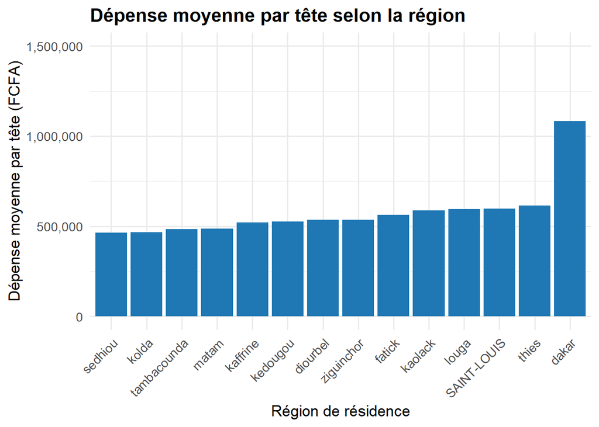

```r
library(ggplot2)
library(dplyr)
library(haven)

welfare_final <- welfare_final %>%
  mutate(region = haven::as_factor(region))

# Calculer la moyenne par région
depense_moyenne <- welfare_final %>%
  group_by(region) %>%
  summarise(pcexp_moy = mean(pcexp, na.rm = TRUE)) %>%
  arrange(desc(pcexp_moy))

# Créer le barplot
ggplot(depense_moyenne, aes(x = reorder(region, pcexp_moy), y = pcexp_moy)) +
  geom_col(fill = "#1f78b4") +
  labs(
    title = "Dépense moyenne par tête selon la région",
    x = "Région de résidence",
    y = "Dépense moyenne par tête (FCFA)"
  ) +
  scale_y_continuous(labels = scales::comma, limits = c(0, 1500000)) +  # Ajuste le max en ordonnées si besoin
  theme_minimal(base_size = 13) +
  theme(
    axis.text.x = element_text(angle = 45, hjust = 1),
    plot.title = element_text(face = "bold")
  )
```